# Direct Mail Fundrasing

Sai Ananthula

# Documentation is at end

## Step 1: Partioning

I used cross validation to estimate out of sample error with seed set to 12345.

### Attaching needed libraries

```r
library(tidyverse)
library(tree)
library(randomForest)
library(gbm)
library(caret)
library(splines)
library(corrplot)
library(kernlab)
```

### Importing Data

```r
train <-  read_rds("fundraising.rds")

test <- read_rds("future_fundraising.rds")
```

## Step 2: Model Building

### Importance table

I used the importance table from a model developed using bagging to explore which predictor variables are or are not relevant

```r
bagged_model <- randomForest(y = train$target, x = train[,1:20], importance = T)

importance(bagged_model)
```

```
                         Donor   No Donor MeanDecreaseAccuracy
zipconvert2          1.5244545 -1.3672339          0.003741136
zipconvert3          3.7582020 -3.5673558          0.294294714
zipconvert4         -0.9767708 -0.7687042         -1.247163089
zipconvert5          2.2426004 -1.8965566          0.103280453
homeowner            0.8606017  0.1122516          0.763577383
num_child            2.6424488  2.2480958          3.393595090
income               3.6190646  0.4898213          2.777660180
female              -1.6835377  0.3581441         -0.971782976
wealth               4.1284361 -3.7628654         -0.096768909
home_value           1.5118650  1.8485930          3.032010278
med_fam_inc          0.2139869  4.6744131          4.933949067
avg_fam_inc         -1.0950623  4.6078703          4.188867534
pct_lt15k            1.3622227  3.2634470          4.041866577
num_prom            -0.3403255  2.5448118          2.250906003
lifetime_gifts       1.8341623 -0.7666477          1.007169998
largest_gift        10.9998356  0.1995323         11.420229130
last_gift            6.2667566 -1.6752504          4.768830657
months_since_donate  6.9307639  6.3858959          9.592496280
time_lag             1.4769218 -1.5475611          0.084410029
avg_gift            10.1633494 -3.4336537          7.260115951
                    MeanDecreaseGini
zipconvert2                 14.99856
zipconvert3                 13.24575
zipconvert4                 14.42954
zipconvert5                 15.61413
homeowner                   16.58753
num_child                   12.92444
income                      66.38888
female                      19.21715
wealth                      49.67969
home_value                 146.66799
med_fam_inc                135.61090
avg_fam_inc                134.63934
pct_lt15k                  112.00553
num_prom                   122.62389
lifetime_gifts             133.18382
largest_gift                80.17086
last_gift                   79.64955
months_since_donate         89.63020
time_lag                    97.87072
avg_gift                   141.28235
```

### Data Transformation & Subseting

However, further exploration is possible starting with stripping non-numeric columns from the dataset (see below). The homeowner and female columns will also be converted to numeric columns.

```r
train <- train[,5:21]
test <- test[,5:20]

train <- train %>%
  mutate(homeowner = as.numeric(homeowner)) %>%
  mutate(female = as.numeric(female))


str(train)
```

```
tibble [3,000 × 17] (S3: tbl_df/tbl/data.frame)
 $ homeowner          : num [1:3000] 1 2 1 1 1 1 1 1 1 1 ...
 $ num_child          : num [1:3000] 1 2 1 1 1 1 1 1 1 1 ...
 $ income             : num [1:3000] 1 5 3 4 4 4 4 4 4 1 ...
 $ female             : num [1:3000] 2 1 2 2 1 1 2 1 1 1 ...
 $ wealth             : num [1:3000] 7 8 4 8 8 8 5 8 8 5 ...
 $ home_value         : num [1:3000] 698 828 1471 547 482 ...
 $ med_fam_inc        : num [1:3000] 422 358 484 386 242 450 333 458 541 203 ...
 $ avg_fam_inc        : num [1:3000] 463 376 546 432 275 498 388 533 575 271 ...
 $ pct_lt15k          : num [1:3000] 4 13 4 7 28 5 16 8 11 39 ...
 $ num_prom           : num [1:3000] 46 32 94 20 38 47 51 21 66 73 ...
 $ lifetime_gifts     : num [1:3000] 94 30 177 23 73 139 63 26 108 161 ...
 $ largest_gift       : num [1:3000] 12 10 10 11 10 20 15 16 12 6 ...
 $ last_gift          : num [1:3000] 12 5 8 11 10 20 10 16 7 3 ...
 $ months_since_donate: num [1:3000] 34 29 30 30 31 37 37 30 31 32 ...
 $ time_lag           : num [1:3000] 6 7 3 6 3 3 8 6 1 7 ...
 $ avg_gift           : num [1:3000] 9.4 4.29 7.08 7.67 7.3 ...
 $ target             : Factor w/ 2 levels "Donor","No Donor": 1 1 2 2 1 1 1 2 1 1 ...
```

### Correlation Table

This table contains the correlation values from 1 (strong positive correlation) to -1 (strong negative correlation) for all pairs of numeric columns in the data set.

```r
cor(train[1:16])
```

```
                        homeowner    num_child       income
homeowner            1.0000000000 -0.045246221 -0.320470476
num_child           -0.0452462210  1.000000000  0.091893089
income              -0.3204704764  0.091893089  1.000000000
female               0.0014784437  0.029596832  0.043813261
wealth              -0.0657703248  0.060175537  0.208993101
home_value          -0.1187277614 -0.011964229  0.291973494
med_fam_inc         -0.1382760204  0.046961647  0.367505334
avg_fam_inc         -0.1334984472  0.047261395  0.378585352
pct_lt15k            0.1375411145 -0.031717891 -0.283191234
num_prom            -0.0032595805 -0.086432604 -0.069008634
lifetime_gifts       0.0281638939 -0.050954766 -0.019565470
largest_gift         0.0333386920 -0.017554416  0.033180760
last_gift            0.0008854337 -0.012948678  0.109592754
months_since_donate -0.0213538579 -0.005563603  0.077238810
time_lag            -0.0262871410 -0.006069356 -0.001545727
avg_gift             0.0083209968 -0.019688680  0.124055750
                          female      wealth    home_value
homeowner            0.001478444 -0.06577032 -0.1187277614
num_child            0.029596832  0.06017554 -0.0119642286
income               0.043813261  0.20899310  0.2919734944
female               1.000000000  0.02938410  0.0209758272
wealth               0.029384095  1.00000000  0.2611611450
home_value           0.020975827  0.26116115  1.0000000000
med_fam_inc          0.023450114  0.37776337  0.7381530742
avg_fam_inc          0.025236799  0.38589230  0.7525690021
pct_lt15k           -0.055176372 -0.37514558 -0.3990861577
num_prom            -0.038218180 -0.41211777 -0.0645138583
lifetime_gifts      -0.037073694 -0.22547332 -0.0240737013
largest_gift        -0.001381799 -0.02527652  0.0564942757
last_gift            0.046359831  0.05259131  0.1588576542
months_since_donate  0.045056823  0.03371398  0.0234285142
time_lag             0.008049159 -0.06642133  0.0006789113
avg_gift             0.074529893  0.09107875  0.1687736865
                    med_fam_inc avg_fam_inc    pct_lt15k
homeowner           -0.13827602 -0.13349845  0.137541114
num_child            0.04696165  0.04726139 -0.031717891
income               0.36750533  0.37858535 -0.283191234
female               0.02345011  0.02523680 -0.055176372
wealth               0.37776337  0.38589230 -0.375145585
```

[output cut: 47 more lines]

```
num_child           -0.0060693555 -0.019688680
income              -0.0015457272  0.124055750
female               0.0080491595  0.074529893
wealth              -0.0664213294  0.091078754
home_value           0.0006789113  0.168773687
med_fam_inc          0.0152020426  0.137162758
avg_fam_inc          0.0243403812  0.131758434
pct_lt15k           -0.0199114896 -0.062480892
num_prom             0.1196232155 -0.147250943
lifetime_gifts       0.0385457538  0.182324349
largest_gift         0.0399770354  0.474830096
last_gift            0.0751112090  0.866399978
months_since_donate  0.0155284995  0.189110799
time_lag             1.0000000000  0.070081643
avg_gift             0.0700816428  1.000000000
```

The raw numbers representing correlation are a little hard to understand so the correlation plots below were built to see which predictors might be collinear.

### Correlation Plots

The 2 plots below are graphical representations of the correlation table above. The first table has just colored squares assigned a color on a scale from blue to red mirroring the 1 to -1 correlation scale. The second has the same color scheme but also features a truncated version of each correlation number.

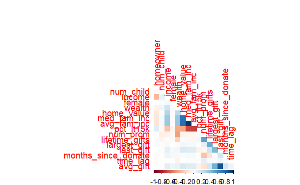

```r
corrplot(cor(train[1:16]),diag= FALSE, method = "color", type = "lower")
```

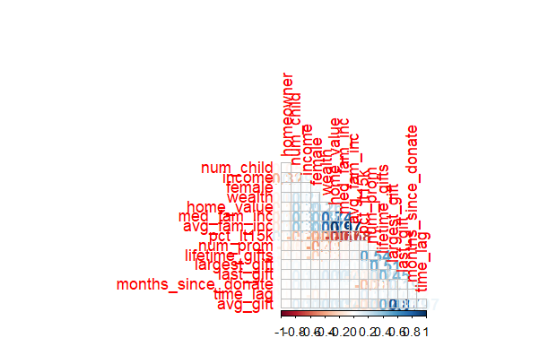

```r
corrplot(cor(train[1:16]),diag= FALSE, method = "number", type = "lower")
```

Strong Correlations: absolute value(corr) > .7 home_value avg_fam_inc med_fam_inc pct_lt15k last_gift avg_gift

There is also a high likelihood avg_fam_inc and median_fam_inc are collinear due their correlation value is .98.

Based on the variables from the importance: largest_gift, avg_gift, last_gift, num_child, and pct_lt15k, months_since_donate.

#### Predictors Used For Model Building: largest_gift, home_value, avg_fam_in, med_fam_inc, pct_lt15k, last_gift, avg_gift, and months_since_donate.

### Random Forest

Originally it was used to figure what predictors would be useful so the model was re-run but with a limited set of predictors.

```r
cv_train <- trainControl(method="repeatedcv", number=5, repeats=3)

set.seed(12345)

randomForest <- train(target ~ home_value + avg_fam_inc + med_fam_inc + pct_lt15k
                           +last_gift + avg_gift + largest_gift +  months_since_donate , data = train, trControl = cv_train,
                           method = "rf")

randomForest
```

```
Random Forest

3000 samples
   8 predictor
   2 classes: 'Donor', 'No Donor'

No pre-processing
Resampling: Cross-Validated (5 fold, repeated 3 times)
Summary of sample sizes: 2400, 2400, 2400, 2400, 2400, 2399, ...
Resampling results across tuning parameters:

  mtry  Accuracy   Kappa
  2     0.5301108  0.06021189
  5     0.5277754  0.05553329
  8     0.5262187  0.05243449

Accuracy was used to select the optimal model using the
 largest value.
The final value used for the model was mtry = 2.
```

The random forest resulted in an accuracy of 0.5301 or 53.01%

### SVM-Radial

A radial SVM was among the three types of SVM’s I tested since one type may have an advantage over the others.

```r
set.seed(12345)

svm_Radial <- train(target ~ home_value + avg_fam_inc + med_fam_inc + pct_lt15k
                           +last_gift + avg_gift+ largest_gift +  months_since_donate, data = train, trControl = cv_train,
                           method = "svmRadial")

svm_Radial
```

```
Support Vector Machines with Radial Basis Function Kernel

3000 samples
   8 predictor
   2 classes: 'Donor', 'No Donor'

No pre-processing
Resampling: Cross-Validated (5 fold, repeated 3 times)
Summary of sample sizes: 2400, 2400, 2400, 2400, 2400, 2399, ...
Resampling results across tuning parameters:

  C     Accuracy   Kappa
  0.25  0.5518854  0.10381857
  0.50  0.5501087  0.10027358
  1.00  0.5462182  0.09248931

Tuning parameter 'sigma' was held constant at a value of 0.273098
Accuracy was used to select the optimal model using the
 largest value.
The final values used for the model were sigma = 0.273098 and C
 = 0.25.
```

The radial SVM resulted in an accuracy of 0.5518 or 55.18%

### SVM-Poly

I also decided to test a polynomial variation of a SVM to see if it would perform better.

```r
set.seed(12345)

svm_Poly<- train(target ~ home_value + avg_fam_inc + med_fam_inc + pct_lt15k
                           +last_gift + avg_gift + largest_gift +  months_since_donate , data = train, trControl = cv_train,
                           method = "svmPoly")

svm_Poly
```

```
Support Vector Machines with Polynomial Kernel

3000 samples
   8 predictor
   2 classes: 'Donor', 'No Donor'

No pre-processing
Resampling: Cross-Validated (5 fold, repeated 3 times)
Summary of sample sizes: 2400, 2400, 2400, 2400, 2400, 2399, ...
Resampling results across tuning parameters:

  degree  scale  C     Accuracy   Kappa
  1       0.001  0.25  0.5237796  0.04814559
  1       0.001  0.50  0.5153320  0.03124031
  1       0.001  1.00  0.5582174  0.11651398
  1       0.010  0.25  0.5484413  0.09666277
  1       0.010  0.50  0.5472183  0.09423796
  1       0.010  1.00  0.5508856  0.10162579
  1       0.100  0.25  0.5519948  0.10387740
  1       0.100  0.50  0.5523280  0.10456059
  1       0.100  1.00  0.5503278  0.10060066
  2       0.001  0.25  0.5149991  0.03057236
  2       0.001  0.50  0.5583287  0.11673278
  2       0.001  1.00  0.5502193  0.10023689
  2       0.010  0.25  0.5561084  0.11223294
  2       0.010  0.50  0.5538846  0.10785745
  2       0.010  1.00  0.5555513  0.11120107
  2       0.100  0.25  0.5527722  0.10565961
  2       0.100  0.50  0.5521067  0.10434127
  2       0.100  1.00  0.5508830  0.10189214
  3       0.001  0.25  0.5497735  0.09977278
  3       0.001  0.50  0.5545522  0.10892245
  3       0.001  1.00  0.5524413  0.10471887
  3       0.010  0.25  0.5531067  0.10628923
  3       0.010  0.50  0.5558835  0.11184268
  3       0.010  1.00  0.5543287  0.10873205
  3       0.100  0.25  0.5492189  0.09842847
  3       0.100  0.50  0.5494422  0.09887937
  3       0.100  1.00  0.5481098  0.09620249

Accuracy was used to select the optimal model using the
 largest value.
The final values used for the model were degree = 2, scale
 = 0.001 and C = 0.5.
```

The polynomial SVM resulted in an accuracy of 0.5583 or 55.83%

### SVM-Linear

I also decided to test a linear variation of a SVM to see if it would perform better.

```r
set.seed(12345)

svm_Linear<- train(target ~ home_value + avg_fam_inc + med_fam_inc + pct_lt15k
                           +last_gift + avg_gift + largest_gift +  months_since_donate, data = train, trControl = cv_train,
                           method = "svmLinear")

svm_Linear
```

```
Support Vector Machines with Linear Kernel

3000 samples
   8 predictor
   2 classes: 'Donor', 'No Donor'

No pre-processing
Resampling: Cross-Validated (5 fold, repeated 3 times)
Summary of sample sizes: 2400, 2400, 2400, 2400, 2400, 2399, ...
Resampling results:

  Accuracy   Kappa
  0.5451069  0.09019354

Tuning parameter 'C' was held constant at a value of 1
```

### Generalized Linear Model

I also decided to see if a generalized linear model since it seems there is a non-linear relationship in effect.

```r
set.seed(12345)

glm_model<- train(target ~ home_value + avg_fam_inc + med_fam_inc + pct_lt15k
                           +last_gift + avg_gift + largest_gift +  months_since_donate , data = train, trControl = cv_train,
                           method = "glm")

glm_model
```

```
Generalized Linear Model

3000 samples
   8 predictor
   2 classes: 'Donor', 'No Donor'

No pre-processing
Resampling: Cross-Validated (5 fold, repeated 3 times)
Summary of sample sizes: 2400, 2400, 2400, 2400, 2400, 2399, ...
Resampling results:

  Accuracy  Kappa
  0.548218  0.09647081
```

The GLM resulted in an accuracy of 0.5482 or 54.82%

### Linear Discriminant Analyis

Since this is classification a linear discriminant approach could be effective.

```r
set.seed(12345)

lda_model<- train(target ~ home_value + avg_fam_inc + med_fam_inc + pct_lt15k
                           +last_gift + avg_gift + largest_gift +  months_since_donate, data = train, trControl = cv_train,
                           method = "lda")

lda_model
```

```
Linear Discriminant Analysis

3000 samples
   8 predictor
   2 classes: 'Donor', 'No Donor'

No pre-processing
Resampling: Cross-Validated (5 fold, repeated 3 times)
Summary of sample sizes: 2400, 2400, 2400, 2400, 2400, 2399, ...
Resampling results:

  Accuracy   Kappa
  0.5471065  0.09425052
```

The LDA resulted in an accuracy of 0.5471 or 54.71%

## Step 3: Testing

SVM-Poly was the most accurate with an accuracy of 0.5583 or 55.83%

```r
set.seed(12345)

svm_Poly_Preds <- predict(svm_Poly, newdata = test)
svm_Poly_Preds <- data.frame(svm_Poly_Preds)
write.csv(svm_Poly_Preds, file = "target.csv", row.names = FALSE)
```

# Documentation

### Business Objectives and Goals

A national veterans organizations wants to increase the effectiveness of their direct-mail campaign. Currently they have a response rate of 5.1% and the average donation is 13USD but that does not account for the cost of each letter which is .68USD. The goals of this analysis is to improve that rate by analyzing a sample of data from their larger data set and look for variables that might influence someone’s decision to donate. By isolating these variables and building a classification model the organization should be able to raise more money whilst spending less money on mass mailing.

### Type of Analyis

The initial analysis step was building a model using bagging since it would tell me which predictor variables were useful for further analysis and which ones were not. Due to this all the zip convert variables were removed from the data set.

A correlation table was then generated to see which predictors variables had some form of correlation with each other regardless if the correlation is positive or negative. The table was not extremely useful due to low-readability so it was then processed into 2 correlation plots that provide a superior graphical representation of the correlation between predictor variables in the data. The first correlation plot is just colored squares colored on a scale from red to blue with red = -1 (strong negative correlation) and blue = 1 (strong positive correlation). This first chart is too quickly see correlations because the second correlation plot also has the number representing the correlation number in each box so you can drill deeper into correlation between predictor variables.

From the importance table from the bagging model and the correlation plot I generated my list of predictor variables: largest_gift, home_value, avg_fam_in, med_fam_inc, pct_lt15k, last_gift, avg_gift, and months_since_donate.

I then decided to build a handful of models to explore different approaches to see which approach would perform the best.

The first model built was a random forest since I originally used bagging to generate an importance table I figured the random forest model would perform well in this classification problem.It performed the worst of all the models.

The fifth model built was generalized linear model since I was curious to how it would perform considering by this point it seemed certain the relationship was non-linear. The GLM’s use of link functions allowed for this to work and the model performed okay.

The sixth and final model was a linear discriminant analysis since GLM performed okay I wanted to see how an LDA would fare on this problem. LDA was used instead of linear regression since this is a classification problem

### Exclusions

Zip codes were removed from the data since they were not relevant to the analysis that was being run.

### Variable Transformations

Female and homeowner had to be converted to the numeric data type so correlation functions could be executed on them.

### Model Performance and Result Validation

For each model I built I used the accuracy calculated by the function due to cross-validation.

SVM-Polynomial was the most accurate so it was the model that was ran on the test data.

| Model \| Accuracy |
| --- |
| Random Forests \| 53.01% |
| SVM-Radial \| 55.18% |
| SVM-Poly \| 55.83% |
| SVM-Linear \| 54.51% |
| GLM \| 54.82% |
| LDA \| 54.71% |